# examples_which_spirolateral

Let's say you want to make a [spirolateral](https://en.wikipedia.org/wiki/Spirolateral).

If the turn angle is $\theta=120^{\circ}$ and the maximum segment length is $n=8$, then which spirolateral is created?

You can use this tool:

https://artockthedino.github.io/pbl/spirolateral/spirolateral_generator.html

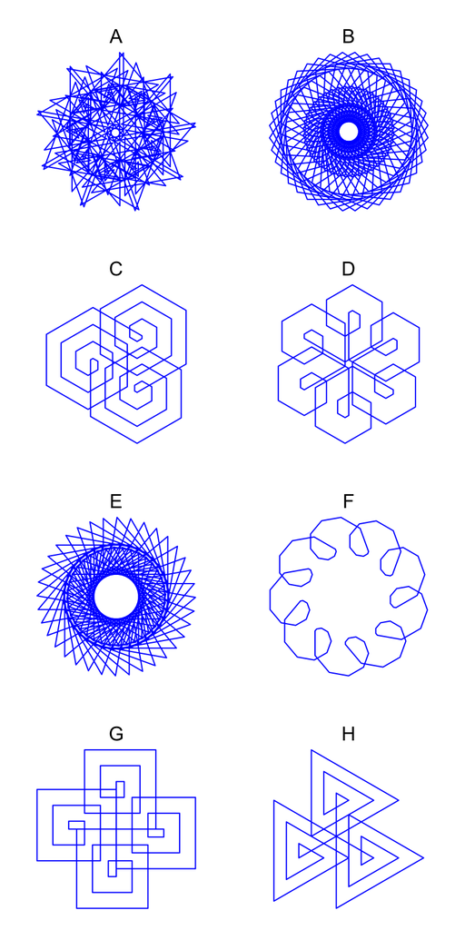

ABCDEFGH

The correct answer is H.

Below I've listed the parameters used to generate all patterns:

- A:
  - Turn angle = 140
  - Count max = 20

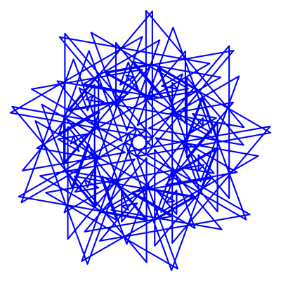

- B:
  - Turn angle = 69
  - Count max = 9

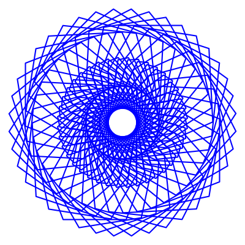

- C:
  - Turn angle = 60
  - Count max = 20

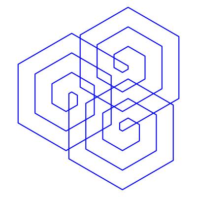

- D:
  - Turn angle = 60
  - Count max = 11

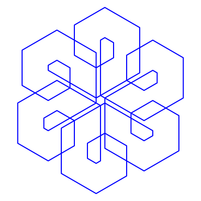

- E:
  - Turn angle = 130
  - Count max = 5

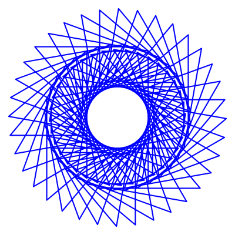

- F:
  - Turn angle = 40
  - Count max = 10

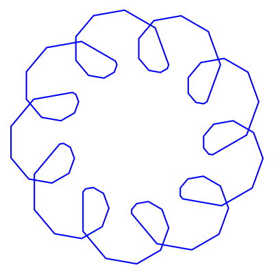

- G:
  - Turn angle = 90
  - Count max = 11

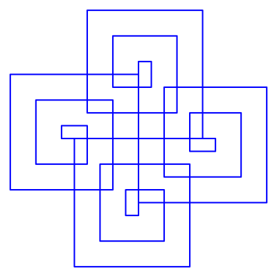

- H:
  - Turn angle = 120
  - Count max = 8

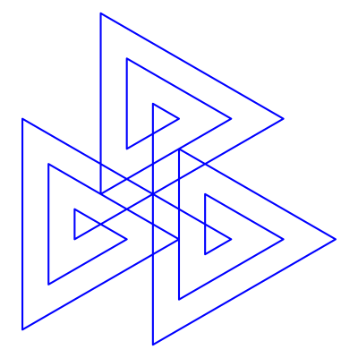

Let's say you want to make a [spirolateral](https://en.wikipedia.org/wiki/Spirolateral).

If the turn angle is $\theta=155^{\circ}$ and the maximum segment length is $n=19$, then which spirolateral is created?

You can use this tool:

https://artockthedino.github.io/pbl/spirolateral/spirolateral_generator.html

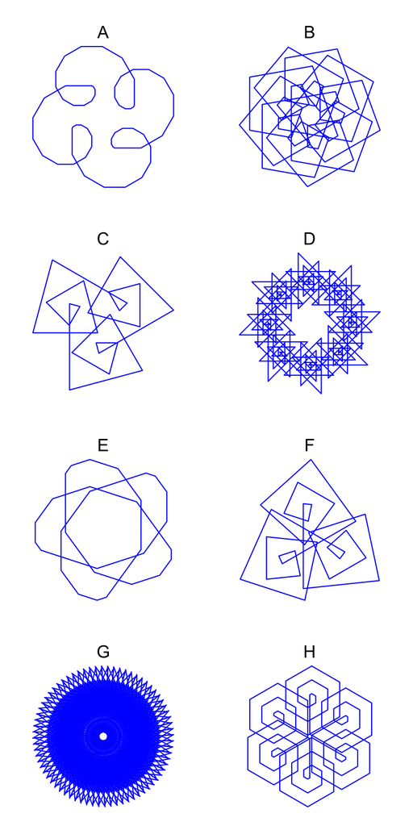

ABCDEFGH

The correct answer is G.

Below I've listed the parameters used to generate all patterns:

- A:
  - Turn angle = 30
  - Count max = 15

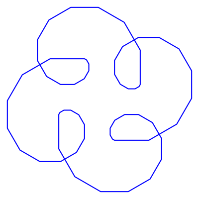

- B:
  - Turn angle = 80
  - Count max = 7

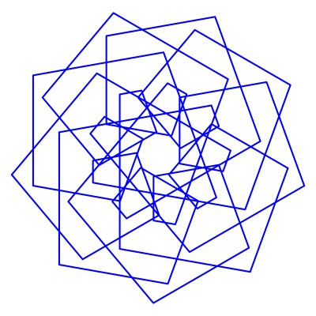

- C:
  - Turn angle = 105
  - Count max = 8

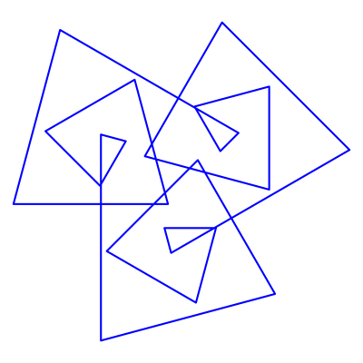

- D:
  - Turn angle = 135
  - Count max = 19

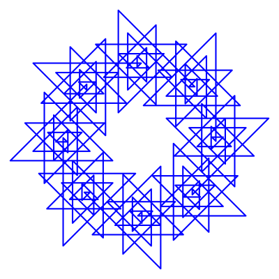

- E:
  - Turn angle = 36
  - Count max = 6

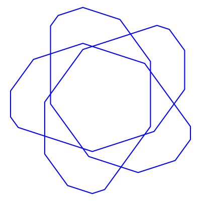

- F:
  - Turn angle = 96
  - Count max = 10

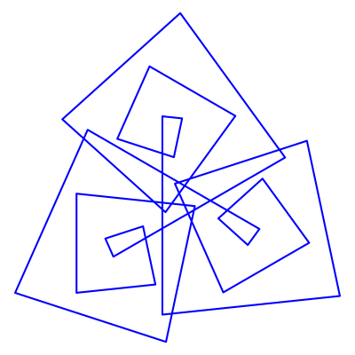

- G:
  - Turn angle = 155
  - Count max = 19

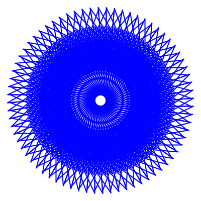

- H:
  - Turn angle = 60
  - Count max = 17

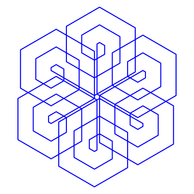

Let's say you want to make a [spirolateral](https://en.wikipedia.org/wiki/Spirolateral).

If the turn angle is $\theta=165^{\circ}$ and the maximum segment length is $n=15$, then which spirolateral is created?

You can use this tool:

https://artockthedino.github.io/pbl/spirolateral/spirolateral_generator.html

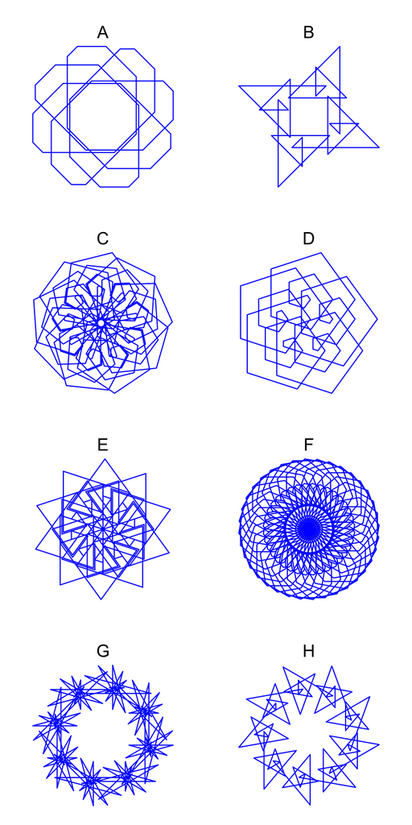

ABCDEFGH

The correct answer is G.

Below I've listed the parameters used to generate all patterns:

- A:
  - Turn angle = 45
  - Count max = 5

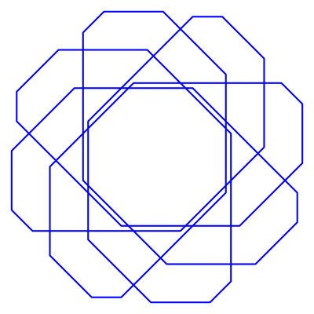

- B:
  - Turn angle = 135
  - Count max = 6

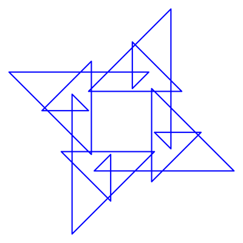

- C:
  - Turn angle = 68
  - Count max = 20

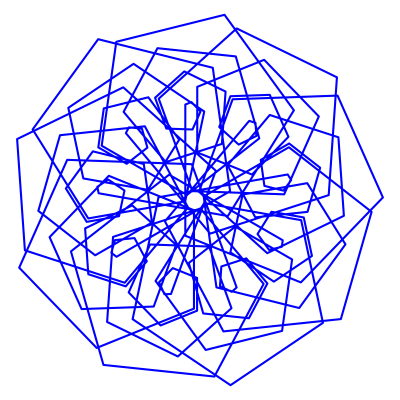

- D:
  - Turn angle = 72
  - Count max = 12

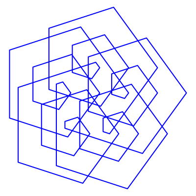

- E:
  - Turn angle = 108
  - Count max = 9

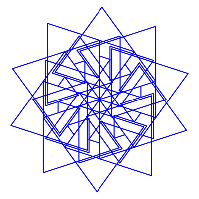

- F:
  - Turn angle = 50
  - Count max = 13

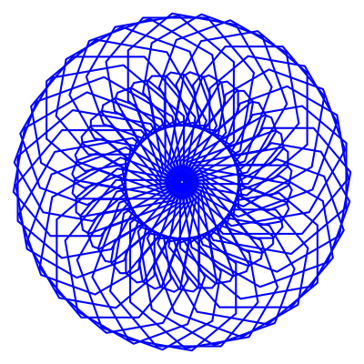

- G:
  - Turn angle = 165
  - Count max = 15

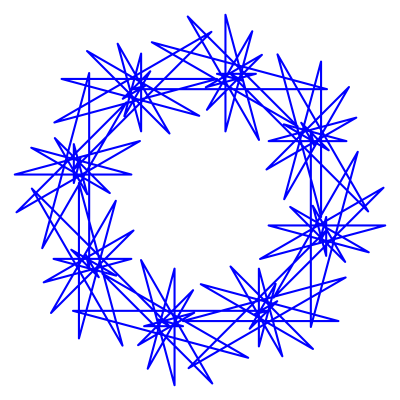

- H:
  - Turn angle = 140
  - Count max = 8

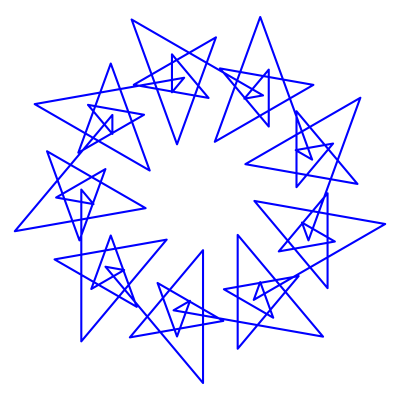

Let's say you want to make a [spirolateral](https://en.wikipedia.org/wiki/Spirolateral).